# 01-Introduction_to_Sets

## Introduction to Sets

### What is a Set?

A set is an unordered collection of items. Every element is unique (no duplicates) and must be immutable (which cannot be changed). However, the set itself is mutable. We can add or remove items from it.

A set is a collection of elements and is usually denoted by a capital letter such as '$S$' or '$A$'.

In general, a set '$U$' known as the universal set consists of all possible elements in a given domain.

A set $A$ is a collection of elements from $U$. These elements will be denoted by lowercase letters, such as a, b, c or x, y, z. These elements are denoted by: $x\in A$ or $x \notin A$ to indicate that “x is an element of $A$” or “x is not an element of $A$” respectively.

### Creating a Set in Python

A set is created/initialized by

1. placing all the items (elements), separated by comma, inside curly braces {}  
   (or)
2. using the built-in function set().

It can have any number of items and they may be of different types (integer, float, tuple, string etc.). But a set cannot have a mutable element, like list, set or dictionary, as its element.

#### Exercise

Initialize a set with the following list elements:

- Apples
- Bananas
- Peaches
- Grapes
- Bananas
- Mangoes
- Bananas

and print it out

### Solution code

```
a = {"Apples","Bananas","Peaches","Grapes","Bananas","Mangoes","Bananas"}
# or
a = set(["Apples","Bananas","Peaches","Grapes","Bananas","Mangoes","Bananas"])
```

### Types of Sets

#### Universal Set

A set which contains all elements of a given space is called a Universal Set. For example, if we are talking about non-negative integers, then the set  
$A = \{0,1,2,3...\infty\}$  
is the Universal Set as it contains all possible elements.

#### Null Set or Empty Set

Empty curly braces {} will initialize an empty dictionary in Python. To make a set without any elements we use the set() function without any argument.

```
# Initializing Null Set
A = set()
```

#### Singleton Set

A set which has one and only one element is called a Singleton Set.

```
# Example of Singleton Set
A = {506}
# or
B = {"Banana"}
```

#### Sub Set

A set which is a part or section of a larger set is called its (the larger set's) subset. Lets say

$A = \{1,2,3,4,5,6,7,8,9,0\}$

and

$B = \{2,4,6,8\}$

now all elements of set $B$ are part of set $A$. Hence, $B$ can be said to be a subset of $A$. The reverse is not true as $A$ has elements that $B$ does not have.

Note: If $A$ and $B$ have the exact same elements then either of them is a subset of the other, i.e. A set is a subset of itself.

#### Super Set

A set which contains all elements of a certain set and may contain some more elements, is called a Superset. Lets say

$A = \{1,2,3,4,5,6,7,8,9,0\}$

and

$B = \{2,4,6,8\}$

now $A$ has all elements of $B$ and some more elements which are not in $B$ and so $A$ contains $B$ and it is called the Superset of $B$.

#### Python functions for subset and superset

There is a special function in python called 'issubset()' which helps check whether a set is a subset of another set. The syntax to use it is given below.

Syntax: subset.issubset(superset) Output: Boolean (True or False)

i.e. If we would like to check whether $B$ is a subset of $A$, then we should type the following.

```
B.issubset(A)
```

Similarly, there is a 'issuperset()' function to check whether a set is a superset of another set. The syntax is as follows.

Syntax: superset.issuperset(subset) Output: Boolean (True or False)

i.e. If we would like to check whether $A$ is a superset of $B$, then we should type the following.

```
A.issuperset(B)
```

#### Immutable Sets

Although the elements of a set can be added or removed, their value itself cannot be changed. Hence, elements of a set are immutable and this is an important set property. We can however, prevent a set from getting manipulated, i.e. elements getting added or deleted, by making the set immutable. Such sets are called 'Frozen Sets' and they can be declared using the 'frozenset()' function.

A python example:

```
S = frozenset([1,2,3])
```

Note that like list of lists, if you are trying to create a set whose elements are also sets, it would raise an error as sets themselves are mutable. So a set with its elements as mutable sets cannot be created. However, if the sets which are to be elemetns of the larger set are declared as immutable/frozen sets, it is possible to create a set of sets.

#### Open and Closed Sets

The concept of open and closed sets is more quantitative in nature. A set containing elements belonging to a certain region without containing boundary elements of that region is called an Open Set. A set containing elements belonging to a certain region along with all elements which define the boundary of that region is called a Closed Set. Though these definitions are simplistic in nature, it may be difficult to understand them without a visual example.

Consider a coordinate system with positive X and positive Y values. Observe the following straight lines:

- $x>3$
- $x<5$
- $y>4$
- $y<6$

The above lines would look like the following in the coordinate system -

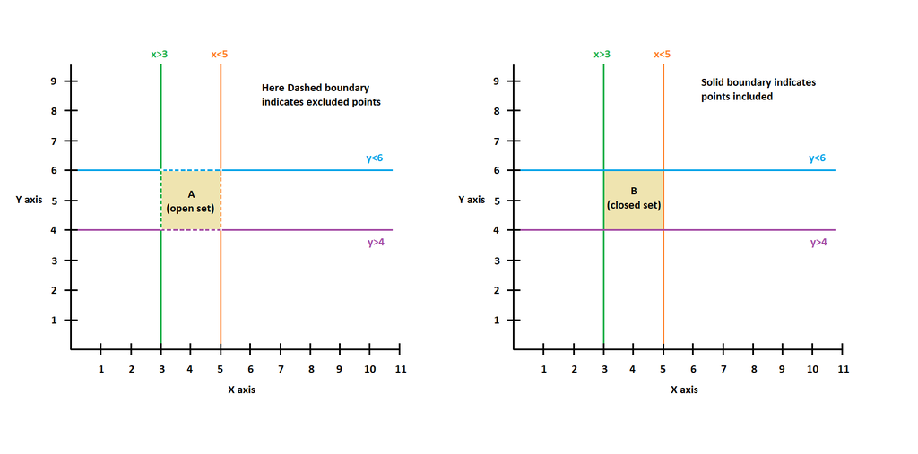

We can see that the above 4 lines enclose a 2X2 square shaped area. Now let me define two sets, $A$ and $B$ -

- $A$ is a set which contains all points within the 2X2 square not including the points on the lines, i.e. $A$ is a collection of all points which satisfy the conditions $x>3$, $x<5$, $y>4$ and $y<6$
- $B$ is a set which contains all points within the 2X2 square, including the points on the lines, i.e. $B$ is a collection of all points which satisfy the conditions $x\geq3$, $x\leq5$, $y\geq4$ and $y\leq6$

Now, as the boundary is not included, $A$ is said to be an 'Open Set' and inclusion of the boundary elements (or points) makes $B$ a 'Closed Set'.

Similarly, if $M$ is a set of all points enclosed by a circle defined by the equation $x^2 + y^2 < 25$, then $M$ is an 'Open Set'. If $N$ is a set of all points enclosed by a circle defined by the equation $x^2 + y^2 < 25$ including the points on the circle with equation $x^2 + y^2 = 25$ then $N$ is said to be a 'Closed Set'. i.e., if $N$ is a collection of all points which satisfy $x^2 + y^2 \leq 25$, then $N$ is a closed set.

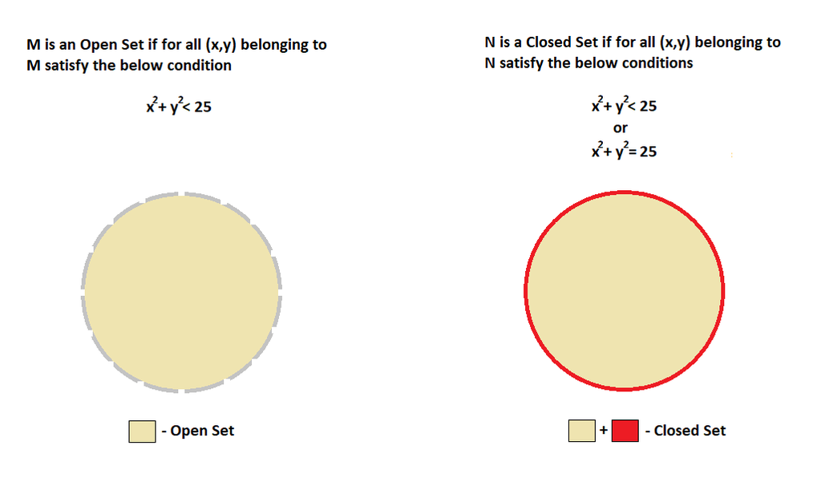

Note: Open and Closed sets are similar to open and closed intervals which are denoted using

- ( ) for open intervals which is exclusive of boundary values
- [ ] for closed intervals which is inclusive of boundary values

#### Exercise

Initialize the following sets:

- $A = \{1,2,3,4,5,6,7,8,9,0\}$
- $B = \{2,4,6,8\}$
- $C$ as a Null set

Verify the following:

- Is $A$ the subset of $B$?
- Is $B$ the superset of $C$?
- Is $A$ the superset of $B$?
- Is $C$ the subset of $A$?

### Solution code

```
A = {1,2,3,4,5,6,7,8,9,0}
B = {2,4,6,8}
C = set()

print(A.issubset(B),B.issuperset(C),A.issuperset(B),C.issubset(A))
```

### Adding and Removing Elements of a Set

We can add single element using the add() method and multiple elements using the update() method. The update() method can take tuples, lists, strings or other sets as its argument. In all cases, duplicates are avoided.

```
my_set = {4,5}
print(my_set)

# Output
>>> {4, 5}


my_set.add(6)
print(my_set)

# Output
>>> {4, 5, 6}
```

Similarly we can remove elements of a set by using the remove() function. The element that is to be removed should be passed as an argument to the remove() function. If the element is not present in the set, the remove() function raises an error. Hence, there is another function called discard(), which removes the element if present, but does not raise an error if the element is not present in the set.

There is also a clear() function which removes all elements of the set and makes it a Null set.

#### Exercise

Using the set $A = \{3,6,4,8,2,0,5,1,9,7\}$ and use appropriate functions to delete the following elements:

Note: Print the set after each operation.

- 9
- 12
- 3
- finally use the clear function to delete all the remaining elements of the set.

### Solution code

```
A = {3,6,4,8,2,0,5,1,9,7}

A.remove(9) # can use remove or discard
print(A)

A.discard(12) # only use discard
print(A)

A.remove(3) # can use remove or discard
print(A)

A.clear()
print(A)
```